# Practical Machine Learning Project

# Load Libraries and Read Files

```r
library(caret)
library(randomForest)
```

```r
library(rattle); library(rpart.plot)
training <- read.table("pml-training.csv", sep=',', stringsAsFactors=F, header=T)
problem <- read.table("pml-testing.csv", sep=',', stringsAsFactors=F, header=T)
```

# Data Processing

## Data Slicing

```r
training$classe <- as.factor(training$classe)
set.seed(100)
inTrain <- createDataPartition(training[,"classe"], p=0.6, list=F)
training <- training[inTrain,]
testing <- training[-inTrain,]
inTest <- createDataPartition(testing[,"classe"], p=0.5, list=F)
testing <- testing[inTest,]
validation <- testing[-inTest,]
```

## Data Cleaning

For the simplicity of this writeup analysis, only the acceleration, magnet and gyros in the x, y, z planes were used as predictor variables. The outcome variable for the training, testing, validation sets is the *classe* variable. The dataset from the *pml-testing.csv* with the classe variable to be predicted is unknown is designated variable **problem**.

```r
predictor <- colnames(training[,grep("\\_[xyz]$" , colnames(training))])
var_problem <-c("problem_id", predictor)
#outcome <- colnames(model.matrix(~classe-1, data=training))
outcome <- "classe"
training <- training[,c(outcome, predictor)]
testing <- testing[,c(outcome, predictor)]
validation <- validation[,c(outcome, predictor)]

problem <- problem[,c("problem_id", predictor)]
```

# Feature Selection

Feature selection was performed using the *findCorrelation* function in the caret package. A cutoff of 0.75 was used to identify predictor variables which were correlated. These variables were removed from the datasets

```r
# highly correlated variables in training set
corMatrix.train <- cor(training[,predictor])
highCor.train <- findCorrelation(corMatrix.train, cutoff=0.75)
print(predictor[-c(highCor.train)])
```

```
##  [1] "gyros_belt_x"      "gyros_belt_y"      "gyros_belt_z"
##  [4] "accel_belt_y"      "magnet_belt_x"     "magnet_belt_y"
##  [7] "magnet_belt_z"     "gyros_arm_y"       "gyros_arm_z"
## [10] "accel_arm_y"       "accel_arm_z"       "magnet_arm_x"
## [13] "gyros_dumbbell_x"  "accel_dumbbell_x"  "accel_dumbbell_y"
## [16] "accel_dumbbell_z"  "magnet_dumbbell_z" "gyros_forearm_x"
## [19] "accel_forearm_x"   "accel_forearm_y"   "accel_forearm_z"
## [22] "magnet_forearm_x"  "magnet_forearm_z"
```

```r
# highly correlated variables in testing set
corMatrix.test <- cor(testing[,predictor])
highCor.test <- findCorrelation(corMatrix.test, cutoff=0.75)
print(predictor[-c(highCor.test)])
```

```
##  [1] "gyros_belt_x"      "gyros_belt_y"      "gyros_belt_z"
##  [4] "accel_belt_y"      "magnet_belt_x"     "magnet_belt_y"
##  [7] "magnet_belt_z"     "gyros_arm_y"       "gyros_arm_z"
## [10] "accel_arm_y"       "accel_arm_z"       "magnet_arm_x"
## [13] "gyros_dumbbell_x"  "gyros_dumbbell_y"  "gyros_dumbbell_z"
## [16] "accel_dumbbell_x"  "accel_dumbbell_y"  "accel_dumbbell_z"
## [19] "magnet_dumbbell_z" "gyros_forearm_x"   "gyros_forearm_y"
## [22] "gyros_forearm_z"   "accel_forearm_x"   "accel_forearm_y"
## [25] "accel_forearm_z"   "magnet_forearm_x"  "magnet_forearm_z"
```

```r
# removal of highly correlated variables
predictor <- predictor[-c(highCor.train)]
training <- training[,c(outcome, predictor)]
testing <- testing[,c(outcome, predictor)]
validation <- validation[,c(outcome, predictor)]
```

# Prediction Function Selection

The random forest and decision trees will be tested as prediction algorithm functions

## Random Forest

```r
modFitRF <- randomForest(x=training[,predictor], y=training[,outcome])
predictRF <- predict(modFitRF, newdata=testing)
confusionMatrix(predictRF, testing$classe)
```

```
## Confusion Matrix and Statistics
##
##           Reference
## Prediction   A   B   C   D   E
##          A 664   0   0   0   0
##          B   0 461   0   0   0
##          C   0   0 411   0   0
##          D   0   0   0 383   0
##          E   0   0   0   0 434
##
## Overall Statistics
##
##                Accuracy : 1
##                  95% CI : (0.9984, 1)
##     No Information Rate : 0.2822
##     P-Value [Acc > NIR] : < 2.2e-16
##
##                   Kappa : 1
##  Mcnemar's Test P-Value : NA
##
## Statistics by Class:
##
##                      Class: A Class: B Class: C Class: D Class: E
## Sensitivity            1.0000   1.0000   1.0000   1.0000   1.0000
## Specificity            1.0000   1.0000   1.0000   1.0000   1.0000
## Pos Pred Value         1.0000   1.0000   1.0000   1.0000   1.0000
## Neg Pred Value         1.0000   1.0000   1.0000   1.0000   1.0000
## Prevalence             0.2822   0.1959   0.1747   0.1628   0.1844
## Detection Rate         0.2822   0.1959   0.1747   0.1628   0.1844
## Detection Prevalence   0.2822   0.1959   0.1747   0.1628   0.1844
## Balanced Accuracy      1.0000   1.0000   1.0000   1.0000   1.0000
```

The use of the random forest method had an accuracy of 1.

## Decision Trees

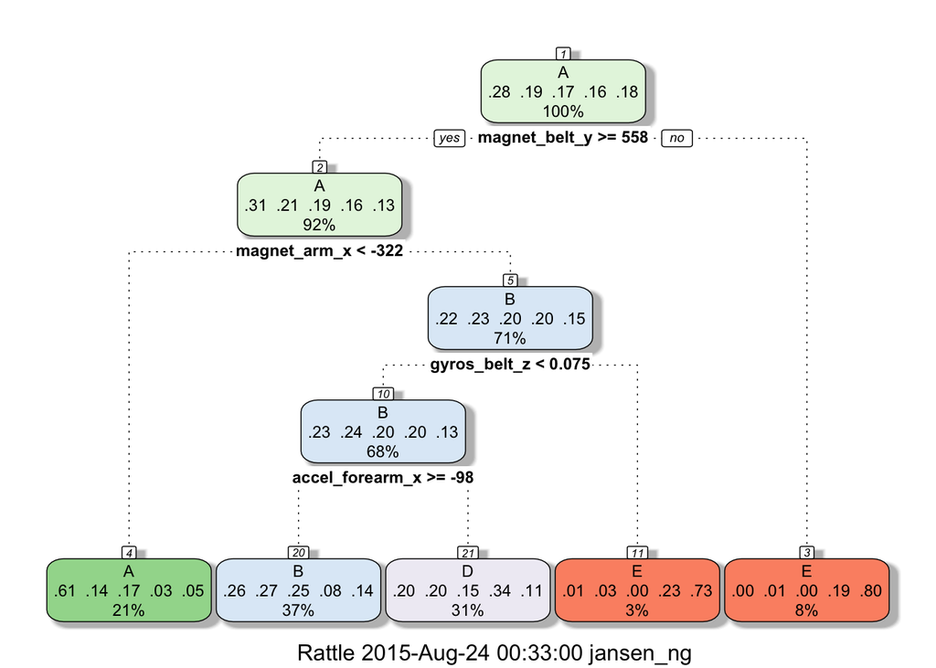

```r
modFitDT <- train(classe~.,method="rpart", data=training)
fancyRpartPlot(modFitDT$finalModel)
```

```r
predictDT <- predict(modFitDT, newdata=testing)
confusionMatrix(predictDT, testing$classe)
```

```
## Confusion Matrix and Statistics
##
##           Reference
## Prediction   A   B   C   D   E
##          A 291  89  96  17  25
##          B 219 237 213  61 117
##          C   0   0   0   0   0
##          D 153 133 101 249  88
##          E   1   2   1  56 204
##
## Overall Statistics
##
##                Accuracy : 0.4169
##                  95% CI : (0.3969, 0.4371)
##     No Information Rate : 0.2822
##     P-Value [Acc > NIR] : < 2.2e-16
##
##                   Kappa : 0.268
##  Mcnemar's Test P-Value : < 2.2e-16
##
## Statistics by Class:
##
##                      Class: A Class: B Class: C Class: D Class: E
## Sensitivity            0.4383   0.5141   0.0000   0.6501   0.4700
## Specificity            0.8656   0.6776   1.0000   0.7589   0.9687
## Pos Pred Value         0.5618   0.2798      NaN   0.3439   0.7727
## Neg Pred Value         0.7967   0.8513   0.8253   0.9177   0.8899
## Prevalence             0.2822   0.1959   0.1747   0.1628   0.1844
## Detection Rate         0.1237   0.1007   0.0000   0.1058   0.0867
## Detection Prevalence   0.2201   0.3600   0.0000   0.3077   0.1122
## Balanced Accuracy      0.6519   0.5958   0.5000   0.7045   0.7194
```

## Application to Validation Set

The model fitted with the random forest algorithm was applied to the validation set, and similarly had perfect accuracy.

```r
predictRFv <- predict(modFitRF, newdata=validation)
confusionMatrix(predictRFv, validation$classe)
```

```
## Confusion Matrix and Statistics
##
##           Reference
## Prediction   A   B   C   D   E
##          A 331   0   0   0   0
##          B   0 235   0   0   0
##          C   0   0 205   0   0
##          D   0   0   0 191   0
##          E   0   0   0   0 208
##
## Overall Statistics
##
##                Accuracy : 1
##                  95% CI : (0.9969, 1)
##     No Information Rate : 0.2829
##     P-Value [Acc > NIR] : < 2.2e-16
##
##                   Kappa : 1
##  Mcnemar's Test P-Value : NA
##
## Statistics by Class:
##
##                      Class: A Class: B Class: C Class: D Class: E
## Sensitivity            1.0000   1.0000   1.0000   1.0000   1.0000
## Specificity            1.0000   1.0000   1.0000   1.0000   1.0000
## Pos Pred Value         1.0000   1.0000   1.0000   1.0000   1.0000
## Neg Pred Value         1.0000   1.0000   1.0000   1.0000   1.0000
## Prevalence             0.2829   0.2009   0.1752   0.1632   0.1778
## Detection Rate         0.2829   0.2009   0.1752   0.1632   0.1778
## Detection Prevalence   0.2829   0.2009   0.1752   0.1632   0.1778
## Balanced Accuracy      1.0000   1.0000   1.0000   1.0000   1.0000
```

# Predict Problem Set

The fitted model was applied to the problem dataset to predict the activity class.

```r
predict(modFitRF, newdata=problem)
```

```
##  1  2  3  4  5  6  7  8  9 10 11 12 13 14 15 16 17 18 19 20
##  B  A  C  A  A  E  D  B  A  A  B  C  B  A  E  E  A  B  B  B
## Levels: A B C D E
```